# Tidy-models-Datacamp-1

John Yuill

# DataCamp course on Tidy Models pkg

[Course](https://campus.datacamp.com/courses/modeling-with-tidymodels-in-r)

## Linear Regression Model

Predicting numerical value of outcome variable.

### Steps:

1. Get Data
2. Split into training / test: initial_split(data, prop, strata))
3. Specify model parameters: () %>% set_engine() %>% set_mode()
4. Fit model: %>% fit(dependent ~ independent, data)
5. Generate predictions with test set to evaluate: predict(, new_data)
6. Bind prediction with test data
7. Evaluate accuracy with rmse: combined test data %>% rmse(truth, estimate)
8. Visualize accuracy for check
9. Modify model inputs as needed to try to improve accuracy

### Get Data

Requirements for predicting numerical outcome:

- numerical independent/predictor values
- numerical dependent/outcome variable
- individual cases with multiple instances of each variable, as opposed to just aggrgated data

Use **soc_search_vid_unit_model_ready.csv** since readily available.

```r
mdata <- read_csv(here('data','soc_search_vid_unit_model_ready.csv'))
head(mdata)
```

```
## # A tibble: 6 x 13
##   product group cat    period     week convo_vol positive_vol neutral_vol
##   <chr>   <chr> <chr>  <chr>     <dbl>     <dbl>        <dbl>       <dbl>
## 1 an      an    Action prelaunch   -37    105289        32376       49905
## 2 an      an    Action prelaunch   -36    101491        40055       36595
## 3 an      an    Action prelaunch   -35     31051         8621       16012
## 4 an      an    Action prelaunch   -34     13891         4166        4813
## 5 an      an    Action prelaunch   -33     29848         9988        9098
## 6 an      an    Action prelaunch   -32     15410         4471        5860
## # … with 5 more variables: negative_vol <dbl>, senti_score_wk <dbl>,
## #   index <dbl>, views <dbl>, units <dbl>
```

### Split into Training and Test sets

- uses functions from rsample pkg
- initial_split function to set up splitting parameters
- prop = % split between two groups (usually set for training group proportion)
- strata = outcome variable, to ensure that each group has equal % representation of the outcome variable

```r
## set up splitting function
mdata_split <- initial_split(mdata,
                             prop=0.8,
                             strata = units)
## get training
mdata_train <- mdata_split %>% training
## get test
mdata_test <- mdata_split %>% testing
```

### Linear Regression

- functions from parsnip pkg
- model object: set up model parameters: model function, set_engine, set_mode
- fit object: apply model parameters to fit a model based on fit values
- tidy(fit object) to get summary output

#### With Convo Vol

```r
## set up model parameters
lr_model <- linear_reg() %>%
  set_engine('lm') %>%
  set_mode('regression')

lr_fit <- lr_model %>%
  fit(units ~ convo_vol, data=mdata_train)

print(lr_fit)
```

```
## parsnip model object
##
## Fit time:  2ms
##
## Call:
## stats::lm(formula = units ~ convo_vol, data = data)
##
## Coefficients:
## (Intercept)    convo_vol
##  -90042.149        3.571
```

```r
tidy(lr_fit)
```

```
## # A tibble: 2 x 5
##   term         estimate std.error statistic  p.value
##   <chr>           <dbl>     <dbl>     <dbl>    <dbl>
## 1 (Intercept) -90042.   37956.        -2.37 1.82e- 2
## 2 convo_vol        3.57     0.283     12.6  4.93e-30
```

#### With Google Search Index

```r
lr_model <- linear_reg() %>%
  set_engine('lm') %>%
  set_mode('regression')

lr_fit <- lr_model %>%
  fit(units ~ index, data=mdata_train)

print(lr_fit)
```

```
## parsnip model object
##
## Fit time:  2ms
##
## Call:
## stats::lm(formula = units ~ index, data = data)
##
## Coefficients:
## (Intercept)        index
##     -114237        34515
```

```r
tidy(lr_fit)
```

```
## # A tibble: 2 x 5
##   term        estimate std.error statistic  p.value
##   <chr>          <dbl>     <dbl>     <dbl>    <dbl>
## 1 (Intercept) -114237.    28315.     -4.03 6.83e- 5
## 2 index         34515.     1608.     21.5  3.82e-64
```

#### With both

```r
lr_model <- linear_reg() %>%
  set_engine('lm') %>%
  set_mode('regression')

lr_fit <- lr_model %>%
  fit(units ~ convo_vol+index, data=mdata_train)

print(lr_fit)
```

```
## parsnip model object
##
## Fit time:  2ms
##
## Call:
## stats::lm(formula = units ~ convo_vol + index, data = data)
##
## Coefficients:
##  (Intercept)     convo_vol         index
## -135698.5829        0.5781    31699.7700
```

```r
tidy(lr_fit)
```

```
## # A tibble: 3 x 5
##   term           estimate std.error statistic  p.value
##   <chr>             <dbl>     <dbl>     <dbl>    <dbl>
## 1 (Intercept) -135699.    30422.        -4.46 1.13e- 5
## 2 convo_vol         0.578     0.307      1.88 6.07e- 2
## 3 index         31700.     2192.        14.5  7.02e-37
```

### Evaluate prediction

- use test data to make predicts based on model and evaluate accuracy
- generate prediction using test data
- bind predictions to test data to compare against actuals
- yardstick pkg: evaluate performance of predictions on test data using functions

#### Generate predictions

- get predictions and combine with actuals

```r
unit_predict <- predict(lr_fit, new_data=mdata_test)

unit_test <- mdata_test %>% select(convo_vol, index, units) %>% bind_cols(unit_predict)

head(unit_test)
```

```
## # A tibble: 6 x 4
##   convo_vol index units    .pred
##       <dbl> <dbl> <dbl>    <dbl>
## 1     31051 1.61  12668  -66692.
## 2      5255 0.840  6175 -106048.
## 3      6721 0.805  5628 -106291.
## 4      4271 0.740  5012 -109759.
## 5      7987 0.610  6087 -111729.
## 6      5827 0.668  4182 -111151.
```

#### Evaluate accuracy

- yardstick pkg: evaluate performance based on accuracy
- rmse
- rsq

```r
## rmse
unit_test %>% rmse(truth=units, estimate=.pred)
```

```
## # A tibble: 1 x 3
##   .metric .estimator .estimate
##   <chr>   <chr>          <dbl>
## 1 rmse    standard     348188.
```

```r
# rsq
unit_test %>% rsq(truth=units, estimate=.pred)
```

```
## # A tibble: 1 x 3
##   .metric .estimator .estimate
##   <chr>   <chr>          <dbl>
## 1 rsq     standard       0.446
```

#### Visualize Performance

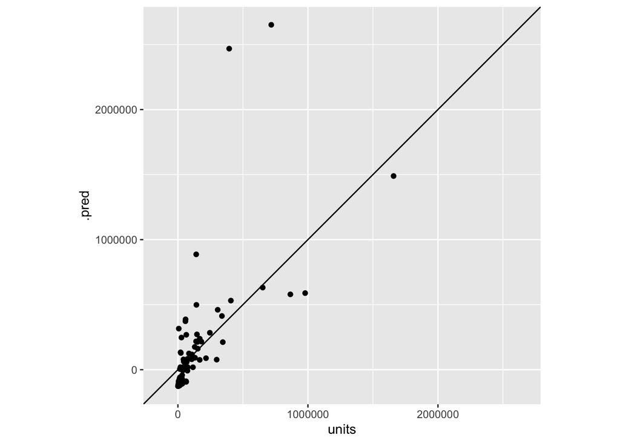

```r
unit_test %>% ggplot(aes(x=units, y=.pred))+geom_point()+
  geom_abline()+ ## diagonal line
  coord_obs_pred() ## scale x, y axes to match
```

## Classification: Logistic Regression

Numerical and/or categorical data with binay outcome variable.

### Steps:

1. Get Data
2. Split into training / test: initial_split(data, prop, strata))
3. Specify model parameters: () %>% set_engine() %>% set_mode()
4. Fit model: %>% fit(dependent ~ independent, data)
5. Generate predictions with test set to evaluate: predict(, new_data)
6. Bind prediction with test data
7. Evaluate accuracy:
   - confusion matrix
   - sensitivity vs specificity
   - other evaluation metrics
   - ROC AUC

### Get Data

- from ISLR pkg - credit card default data

```r
ccdata <- Default
head(ccdata)
```

```
##   default student   balance    income
## 1      No      No  729.5265 44361.625
## 2      No     Yes  817.1804 12106.135
## 3      No      No 1073.5492 31767.139
## 4      No      No  529.2506 35704.494
## 5      No      No  785.6559 38463.496
## 6      No     Yes  919.5885  7491.559
```

```r
str(ccdata)
```

```
## 'data.frame':    10000 obs. of  4 variables:
##  $ default: Factor w/ 2 levels "No","Yes": 1 1 1 1 1 1 1 1 1 1 ...
##  $ student: Factor w/ 2 levels "No","Yes": 1 2 1 1 1 2 1 2 1 1 ...
##  $ balance: num  730 817 1074 529 786 ...
##  $ income : num  44362 12106 31767 35704 38463 ...
```

Note that the outcome variable - default - is a binary variable, with class = factor and factors in order ‘No’ and ‘Yes’. This will mess up modelling because will assume that first factor = positive outcome.

Need to relevel to avoid confusion in the confusion matrix.

```r
## need to relevel outcome variable to have 'positive' outcome first
## - this will flow through to training and test data sets and for both actual and ## predicted classification
ccdata$default <- fct_relevel(ccdata$default, "Yes","No")
## confirm
str(ccdata)
```

```
## 'data.frame':    10000 obs. of  4 variables:
##  $ default: Factor w/ 2 levels "Yes","No": 2 2 2 2 2 2 2 2 2 2 ...
##  $ student: Factor w/ 2 levels "No","Yes": 1 2 1 1 1 2 1 2 1 1 ...
##  $ balance: num  730 817 1074 529 786 ...
##  $ income : num  44362 12106 31767 35704 38463 ...
```

### Split to Training / Test

```r
set.seed(2021) ## set seed to preserve same test / training if recreated later
cc_split <- initial_split(data=ccdata, prop=0.75, strata=default)
cc_training <- cc_split %>% training
cc_test <- cc_split %>% testing

nrow(cc_training)
```

```
## [1] 7500
```

```r
nrow(cc_test)
```

```
## [1] 2500
```

```r
## check distribution of default / not default for training and test set
table(cc_training$default)
```

```
##
##  Yes   No
##  242 7258
```

```r
table(cc_test$default)
```

```
##
##  Yes   No
##   91 2409
```

### Logistic Regression

Create model on training set.

```r
## function from parsnip
## specify the model
logr_model <- logistic_reg() %>%
  ## set engine
  set_engine('glm') %>%
  ## set mode
  set_mode('classification')

## fit model to training data - numerical data only
logr_fit <- logr_model %>% fit(default ~ balance + income, data=cc_training)

## Print model
logr_fit
```

```
## parsnip model object
##
## Fit time:  13ms
##
## Call:  stats::glm(formula = default ~ balance + income, family = stats::binomial,
##     data = data)
##
## Coefficients:
## (Intercept)      balance       income
## 11.79601416  -0.00570147  -0.00002505
##
## Degrees of Freedom: 7499 Total (i.e. Null);  7497 Residual
## Null Deviance:       2138
## Residual Deviance: 1145  AIC: 1151
```

### Generate Predictions

- run prediction on test set
- produces data frame with 1 var: .pred_class (since classification model)
- bind predictions to test set for comparison with actual classifications

```r
default_predict_class <- predict(logr_fit, new_data=cc_test, type='class')

default_test <- cc_test %>% bind_cols(default_predict_class)

head(default_test)
```

```
##   default student   balance    income .pred_class
## 1      No     Yes  919.5885  7491.559          No
## 2      No     Yes  808.6675 17600.451          No
## 3      No      No 1112.9684 23810.174          No
## 4      No      No  286.2326 45042.413          No
## 5      No     Yes  527.5402 17636.540          No
## 6      No      No  773.2117 34353.314          No
```

```r
default_predict_prob <- predict(logr_fit, new_data=cc_test, type='prob')

default_test <- default_test %>% bind_cols(default_predict_prob)

head(default_test)
```

```
##   default student   balance    income .pred_class    .pred_Yes  .pred_No
## 1      No     Yes  919.5885  7491.559          No 0.0017172072 0.9982828
## 2      No     Yes  808.6675 17600.451          No 0.0011759435 0.9988241
## 3      No      No 1112.9684 23810.174          No 0.0077369222 0.9922631
## 4      No      No  286.2326 45042.413          No 0.0001190684 0.9998809
## 5      No     Yes  527.5402 17636.540          No 0.0002371829 0.9997628
## 6      No      No  773.2117 34353.314          No 0.0014612876 0.9985387
```

### Evaluate Model

Evaluate predictions.

- Functions from **Yardstick** pkg
- consistent values/structure for all the functions showcased below

#### Confusion Matrix

- Specify data set, ‘truth’ column, ‘estimate’ column

```r
## get confusion matrix
confusion <- conf_mat(default_test,
                      truth=default,
                      estimate=.pred_class)
confusion
```

```
##           Truth
## Prediction  Yes   No
##        Yes   28    8
##        No    63 2401
```

```r
no_percent <- sum(confusion$table[,2])/sum(confusion$table)
```

#### Check Accuracy

- accuracy functio same values/structure as conf_matrix - easy!
- calculated as % correct: true positives and true negatives divided by all
  - (TP+TN)/(TP+FP+TN+FN)
- generally NOT the best metric - esp if inbalance, predicting dominant class for all will yield high accuracy.
- above confusion matrix shows ‘No’ is 96.36 % of total, so just predicting ALL as No will give 96.36 % accuracy.

```r
accuracy(default_test,
         truth=default,
         estimate=.pred_class)
```

```
## # A tibble: 1 x 3
##   .metric  .estimator .estimate
##   <chr>    <chr>          <dbl>
## 1 accuracy binary         0.972
```

- better than just predicting all as ‘No’ in this case, but more nuanced evaluation is useful

#### Sensitivity

- Sensitivity evaluates how many Positives (‘Yes’ in this case) were correctly identified
- Improves with True Positive Rate (prediced positive when actually positive)
- Low sensitivity means tendency to under-predict positives
- sens function same values/structure as conf_matrix & accuracy - easy!

```r
sens(default_test, truth=default, estimate=.pred_class)
```

```
## # A tibble: 1 x 3
##   .metric .estimator .estimate
##   <chr>   <chr>          <dbl>
## 1 sens    binary         0.308
```

- Sensitivity is LOW so the model is missing lots of Positives and classifying incorrectly as Negative
- Very conservative model, unable to confidently differentiate positives from negatives, reluctant to over-commit to positives

#### Specificity

- Specificity evaluates how many Negatives (‘No’ in this case) were correctly identified
- Improves with True Negative Rate (predicted negative when actually negative)
- Low specificity means tendency to over-predict positives, generating False Positives
- False Positive Rate = 1-Specificity
- spec function same values/structure as conf_matrix & accuracy & sens - easy!

```r
spec(default_test, truth=default, estimate=.pred_class)
```

```
## # A tibble: 1 x 3
##   .metric .estimator .estimate
##   <chr>   <chr>          <dbl>
## 1 spec    binary         0.997
```

- Very low False Positive Rate
- Erring on the side of negatives, not wanting to make mistakes on the positive side
- Could be good in situations where it is more desirable to catch the positives that you are sure of and ok with letting some positives slip through, rather than falsely declaring positives
  - when limited resources to act on positives and want to have high confidence that the ones acting on are actually positive
  - stakes of letting positives through is not high (marketing re-targeting vs deadly disease)

#### Combine Accuracy, Sensitivity, Specificity

- Custom metric by using metric_set() function in Yardstick
- metric_set function same values/structure as conf_matrix & accuracy & sens & spec - easy!

```r
custom_metric_combo <- metric_set(accuracy, sens, spec)
custom_metric_combo(default_test, truth=default, estimate=.pred_class)
```

```
## # A tibble: 3 x 3
##   .metric  .estimator .estimate
##   <chr>    <chr>          <dbl>
## 1 accuracy binary         0.972
## 2 sens     binary         0.308
## 3 spec     binary         0.997
```

- Tells combined story on model accuracy/effectiveness in one place
- Good or Bad? Depends on purpose
- Accuracy is high - but needs to be compared to blanket classification
- Sensitivity is low - depends how important it is to catch ALL the positives
  - may want a model that has higher likelihood of correctly classifying true positives
- Specificity is high - depends on tolerance for false positives
  - may want model that is not as strict and accepts more mis-classification of positives - IF also improves sensitivity to true positives

#### ALL metrics

- ALL the Binary Classification metrics within Yardstick
- conf_mat > summary
- Yardstick reference - for more info

```r
conf_mat(default_test, truth=default, estimate=.pred_class) %>%
  summary()
```

```
## # A tibble: 13 x 3
##    .metric              .estimator .estimate
##    <chr>                <chr>          <dbl>
##  1 accuracy             binary        0.972
##  2 kap                  binary        0.429
##  3 sens                 binary        0.308
##  4 spec                 binary        0.997
##  5 ppv                  binary        0.778
##  6 npv                  binary        0.974
##  7 mcc                  binary        0.478
##  8 j_index              binary        0.304
##  9 bal_accuracy         binary        0.652
## 10 detection_prevalence binary        0.0144
## 11 precision            binary        0.778
## 12 recall               binary        0.308
## 13 f_meas               binary        0.441
```

#### Visualize Model Results

- Heatmap

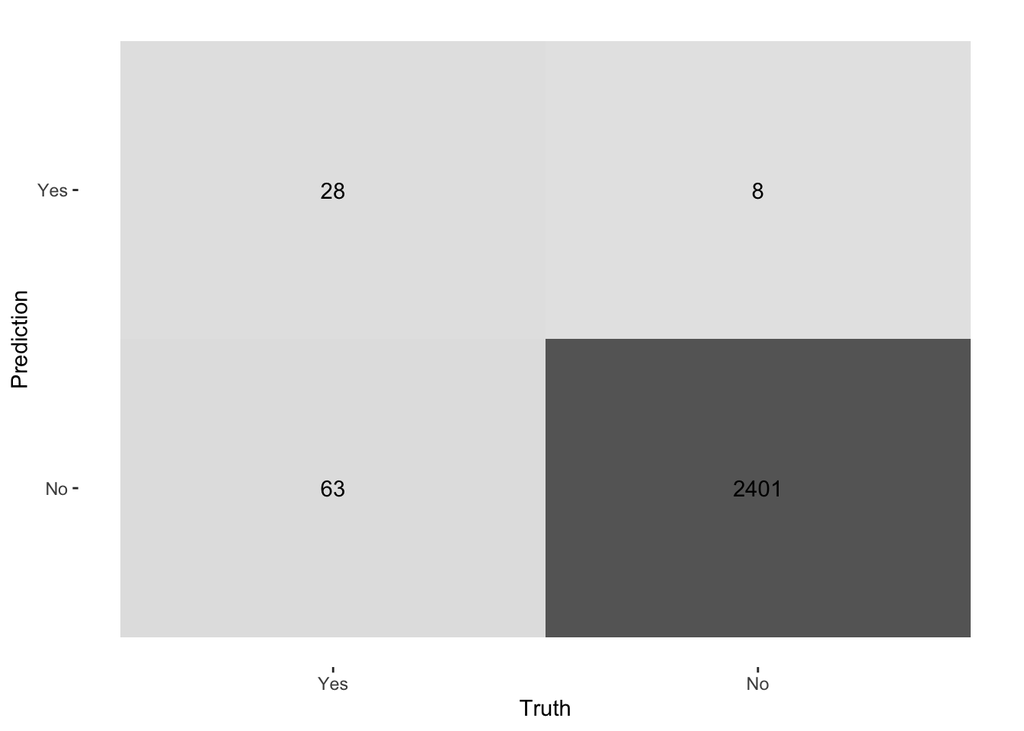

```r
conf_mat(default_test, truth=default, estimate=.pred_class) %>%
  autoplot(type='heatmap')
```

- mosaic: balances columns based on proportions

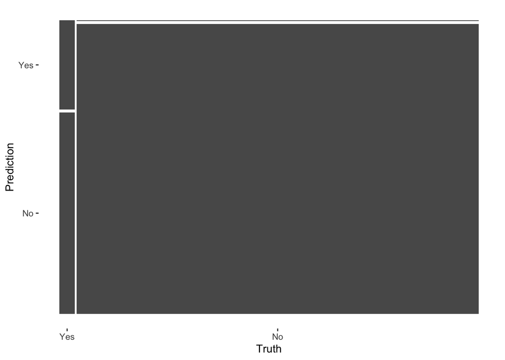

```r
conf_mat(default_test, truth=default, estimate=.pred_class) %>%
  autoplot(type='mosaic')
```

#### ROC Curve!

- Recieving Operating Characteristic (ROC) Curve
- Visualize performance across probability thresholds
- Sensitivity (Y-axis) vs 1-Specificity (X-axis)
- Optimal: 0,1
- Diagonal is poor performance -> random 50/50

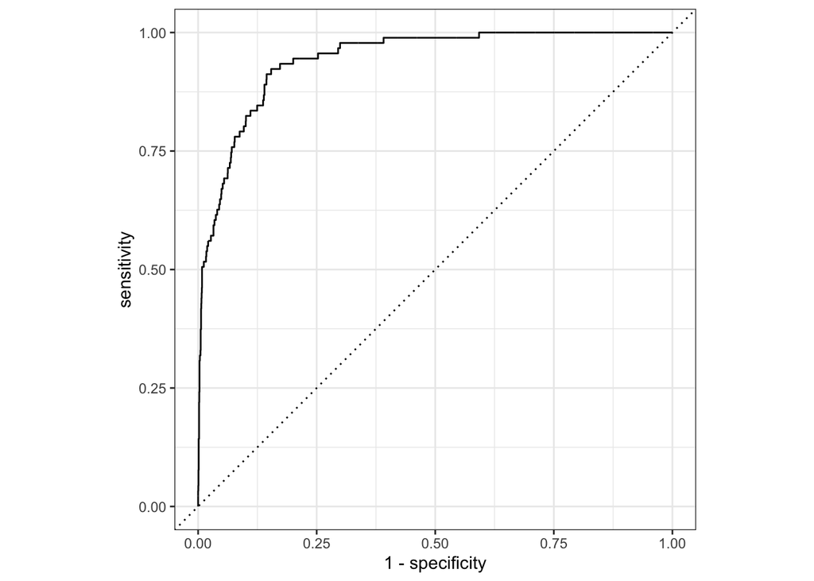

```r
default_test %>% roc_curve(truth=default, .pred_Yes) %>% autoplot()
```

#### ROC AUC

- calculate area under ROC curve
- gives overall performance and enables comparison to alternate models

```r
default_test %>% roc_auc(truth=default, .pred_Yes)
```

```
## # A tibble: 1 x 3
##   .metric .estimator .estimate
##   <chr>   <chr>          <dbl>
## 1 roc_auc binary         0.944
```

- Seems like very high AUC - I guess function largely of low false positive rate (1-specificity)

## Automation

Use last_fit to combine model fit and test in one step.

### Fit model and evaluate

```r
## need model params and split object
# logr_model
# cc_split

cc_last_fit <- logr_model %>%
  last_fit(default ~ student+balance+income, split=cc_split)

cc_last_fit %>% collect_metrics()
```

```
## # A tibble: 2 x 4
##   .metric  .estimator .estimate .config
##   <chr>    <chr>          <dbl> <chr>
## 1 accuracy binary         0.971 Preprocessor1_Model1
## 2 roc_auc  binary         0.945 Preprocessor1_Model1
```

### Customize metrics

```r
cc_last_fit_results <- cc_last_fit %>% collect_predictions()
cc_last_fit_results
```

```
## # A tibble: 2,500 x 7
##    id             .pred_Yes .pred_No  .row .pred_class default .config
##    <chr>              <dbl>    <dbl> <int> <fct>       <fct>   <chr>
##  1 train/test sp…  0.00169     0.998     6 No          No      Preprocessor1_Mo…
##  2 train/test sp…  0.00102     0.999     8 No          No      Preprocessor1_Mo…
##  3 train/test sp…  0.00984     0.990    15 No          No      Preprocessor1_Mo…
##  4 train/test sp…  0.000113    1.00     16 No          No      Preprocessor1_Mo…
##  5 train/test sp…  0.000202    1.00     18 No          No      Preprocessor1_Mo…
##  6 train/test sp…  0.00161     0.998    25 No          No      Preprocessor1_Mo…
##  7 train/test sp…  0.000837    0.999    27 No          No      Preprocessor1_Mo…
##  8 train/test sp…  0.000125    1.00     32 No          No      Preprocessor1_Mo…
##  9 train/test sp…  0.0362      0.964    35 No          No      Preprocessor1_Mo…
## 10 train/test sp…  0.0145      0.985    52 No          No      Preprocessor1_Mo…
## # … with 2,490 more rows
```

```r
## check confusion matrix - make sure factor levels are in order with 'positive' first
conf_mat(cc_last_fit_results,
                      truth=default,
                      estimate=.pred_class)
```

```
##           Truth
## Prediction  Yes   No
##        Yes   29   10
##        No    62 2399
```

```r
## select custom metrics of interest
cc_last_fit_metrics <- metric_set(accuracy,
                                  sens,
                                  spec,
                                  roc_auc)
## produce custom metrics - should match results in original log reg above
cc_last_fit_metrics(cc_last_fit_results,
                    truth=default,
                    estimate=.pred_class,
                    .pred_Yes)
```

```
## # A tibble: 4 x 3
##   .metric  .estimator .estimate
##   <chr>    <chr>          <dbl>
## 1 accuracy binary         0.971
## 2 sens     binary         0.319
## 3 spec     binary         0.996
## 4 roc_auc  binary         0.945
```

```r
#sens(cc_last_fit_results, truth=default, estimate=.pred_class)
#roc_auc(cc_last_fit_results, truth=default, .pred_Yes)
```

## Feat. Eng.

Feature Engineering using recipes pkg via tidymodels (back to original credit card data (ccdata))

- set up the model: logistic regression in this case

### Numerical Data

(sidebar: adding a var to demonstrate how to handle multicolinearity)

```r
## add col based on calc from existing col to demonstrate how to handle multi-collinearity
ccdata2 <- ccdata
## create new var with controlled random factor of existing var
for(f in 1:nrow(ccdata2)){
  ccdata2$fakevar[f] <- ccdata2$balance[f]*rnorm(1, mean=12, sd=2.5)
}
## looking for correlation coefficient 0.9-0.98
cor(ccdata2$balance, ccdata2$fakevar)
```

```
## [1] 0.9226546
```

```r
## split new data to training and test
cc2_split <- initial_split(data=ccdata2, prop=0.8, strata=default)
cc2_train <- cc2_split %>% training()
cc2_test <- cc2_split %>% testing()
```

Create recipe that prepares data for modeling from original ingredients.

- step_corr: identify and remove highly correlated variables, based on threshold
- step_normalize: rescale data by value-mean/sd
- step_range also demonstrated: rescale variables within specified range
- ‘bake’ the prepared data set

```r
cc2_recipe <- recipe(default ~.,
                     data=cc2_train) %>%
  step_corr(all_numeric(), threshold = 0.9) %>%
  step_normalize(all_numeric())

cc2_recipe
```

```
## Data Recipe
##
## Inputs:
##
##       role #variables
##    outcome          1
##  predictor          4
##
## Operations:
##
## Correlation filter on all_numeric()
## Centering and scaling for all_numeric()
```

```r
cc2_recipe %>% prep(training=cc2_train) %>% bake(new_data=NULL)
```

```
## # A tibble: 8,000 x 4
##    student income fakevar default
##    <fct>    <dbl>   <dbl> <fct>
##  1 No       0.817 -0.344  No
##  2 Yes     -1.60  -0.513  No
##  3 No      -0.128  0.0859 No
##  4 No       0.168 -0.292  No
##  5 No       0.374 -0.130  No
##  6 Yes     -1.95   0.884  No
##  7 No      -0.314 -1.62   No
##  8 Yes     -0.869 -1.62   No
##  9 Yes     -1.51   0.724  No
## 10 No      -0.391 -1.03   No
## # … with 7,990 more rows
```

```r
## can also use step_range with min and max if you want to normalize variables
##  within a specified range (0-100 in this case):
cc2_rec_rng <- recipe(default ~ ., data=cc2_train) %>%
  step_range(all_numeric(), min=0, max=100)

cc2_rec_rng %>%
  prep(training=cc2_train) %>%
  bake(new_data=NULL)
```

```
## # A tibble: 8,000 x 5
##    student balance income fakevar default
##    <fct>     <dbl>  <dbl>   <dbl> <fct>
##  1 No        29.1   59.9    20.4  No
##  2 Yes       32.7   15.6    17.7  No
##  3 No        42.9   42.6    27.3  No
##  4 No        21.1   48.0    21.2  No
##  5 No        31.4   51.8    23.8  No
##  6 Yes       36.7    9.23   40.0  No
##  7 No         0     39.2     0    No
##  8 Yes        0     29.0     0    No
##  9 Yes       48.8   17.2    37.5  No
## 10 No         9.47  37.8     9.43 No
## # … with 7,990 more rows
```

- ‘balance’ col is removed due to multicolinearity
- remaining cols are normalized (value-mean/sd)

Cool but don’t know how to control/influence which columns remain when multi-colinearity is detected. Prefer to keep ‘balance’ rather than ‘fakevar’.

(going back to original ccdata)

- similar preparation according to recipe
- use the recipe to ‘bake’ the test data into same preparation (new_data=cc_test)

```r
## create recipe with prep steps
cc_recipe <- recipe(default ~.,
                     data=cc_training) %>%
  step_corr(all_numeric(), threshold = 0.9) %>%
  step_normalize(all_numeric())
## check recipe
cc_recipe
```

```
## Data Recipe
##
## Inputs:
##
##       role #variables
##    outcome          1
##  predictor          3
##
## Operations:
##
## Correlation filter on all_numeric()
## Centering and scaling for all_numeric()
```

```r
## apply recipe to training data
cc_recipe_prep <- cc_recipe %>% prep(training=cc_training)

## apply to test data
cc_recipe_prep %>% bake(new_data=cc_test)
```

```
## # A tibble: 2,500 x 4
##    student balance  income default
##    <fct>     <dbl>   <dbl> <fct>
##  1 Yes      0.180  -1.94   No
##  2 Yes     -0.0498 -1.19   No
##  3 No       0.581  -0.725  No
##  4 No      -1.13    0.863  No
##  5 Yes     -0.633  -1.19   No
##  6 No      -0.123   0.0637 No
##  7 No      -0.393   0.596  No
##  8 Yes     -0.796  -1.32   No
##  9 Yes      1.23   -0.812  No
## 10 Yes      0.933  -1.52   No
## # … with 2,490 more rows
```

Can now evaluate the model on the test data, which is in the same form of the training data, thanks to the same recipe being baked.

(detour to work on categorical data before getting back to modeling and evaluation)

### Categorical Data

aka ‘Nominal’ data

- similar workflow as with numerical data
- convert nominal (categorical) data into numerical, based on whether or not a record is associated with each category item

Create dummy variables

- ‘student’ is nominal variable, currently expressed as ‘Yes’ or ‘No’
- step_dummy converts to dummy variable, where student_Yes is either 0 or 1
- always 1-less dummy variables than values for the nominal variable, since by definition the value of the remaining (dropped) nominal variable will be dictated by the other variables
  - if student_Yes = 1, then by definition student_No = 0 (and vice versa) so no need to include in model

```r
## create recipe with prep steps
cc_recipe <- recipe(default ~.,
                     data=cc_training) %>%
  step_dummy(all_nominal(), -all_outcomes()) ## converts all nominal variables in data set to dummy variables, except outcome variable

## check recipe
cc_recipe
```

```
## Data Recipe
##
## Inputs:
##
##       role #variables
##    outcome          1
##  predictor          3
##
## Operations:
##
## Dummy variables from all_nominal(), -all_outcomes()
```

```r
## apply recipe to training data
cc_recipe_prep <- cc_recipe %>% prep(training=cc_training)

## apply to test data
cc_recipe_prep %>% bake(new_data=cc_test)
```

```
## # A tibble: 2,500 x 4
##    balance income default student_Yes
##      <dbl>  <dbl> <fct>         <dbl>
##  1    920.  7492. No                1
##  2    809. 17600. No                1
##  3   1113. 23810. No                0
##  4    286. 45042. No                0
##  5    528. 17637. No                1
##  6    773. 34353. No                0
##  7    643. 41474. No                0
##  8    449. 15799. No                1
##  9   1424. 22634. No                1
## 10   1283. 13121. No                1
## # … with 2,490 more rows
```

```r
## COMBINE recipe steps into single process
recipe(default ~ ., data=cc_training) %>%
  step_dummy(all_nominal(), -all_outcomes()) %>%
  prep(training=cc_training) %>%
  bake(new_data=cc_test)
```

```
## # A tibble: 2,500 x 4
##    balance income default student_Yes
##      <dbl>  <dbl> <fct>         <dbl>
##  1    920.  7492. No                1
##  2    809. 17600. No                1
##  3   1113. 23810. No                0
##  4    286. 45042. No                0
##  5    528. 17637. No                1
##  6    773. 34353. No                0
##  7    643. 41474. No                0
##  8    449. 15799. No                1
##  9   1424. 22634. No                1
## 10   1283. 13121. No                1
## # … with 2,490 more rows
```

## Workflow I

Combining everything covered so far into complete Classification Model workflow.

### Summary steps

1. Split data into training / test
2. Model specification
3. Feature engineering (independent of model spec - could be done before)
4. Model fitting
5. Model prediction
6. Model evaluation

### 1. Split data into training / test

```r
set.seed(2021) ## set seed same as earlier to generate same training / test data
cc_split <- initial_split(ccdata, prop=0.75, strat=default)
cc_train_cat <- cc_split %>% training()
cc_test_cat <- cc_split %>% testing()
```

```
## New training and test data for categorical variable inclusion:
```

```
## [1] 7500
```

```
## [1] 2500
```

```
##
##  Yes   No
##  242 7258
```

```
##
##  Yes   No
##   91 2409
```

```
## Original training and test data for first model:
```

```
## [1] 7500
```

```
## [1] 2500
```

```
##
##  Yes   No
##  242 7258
```

```
##
##  Yes   No
##   91 2409
```

### 2. Model Specification

- logistic regression for categorical outcome (default / not default)

```r
## specify the model type
cc_logreg_model <- logistic_reg() %>%
  set_engine('glm') %>%
  set_mode('classification')
```

### 3. Feature Engineering

#### Recipe

- resolve multi-collinearity by removing redundant variables
- normalize numeric variables
- create dummy variables for nominal
- bake the recipe based on above

```r
cc_logreg_recipe <- recipe(default ~ ., data=cc_train_cat) %>%
  step_corr(all_numeric()) %>% ## remove correlated numeric variables
  step_normalize(all_numeric()) %>% ## normalize numeric variables
  step_dummy(all_nominal(), -all_outcomes()) %>% ## convert nominal to dummy vars
  prep(training = cc_train_cat)
cc_logreg_recipe
```

```
## Data Recipe
##
## Inputs:
##
##       role #variables
##    outcome          1
##  predictor          3
##
## Training data contained 7500 data points and no missing data.
##
## Operations:
##
## Correlation filter removed no terms [trained]
## Centering and scaling for balance, income [trained]
## Dummy variables from student [trained]
```

```r
## bake training data with recipe for modeling
cc_train_prep <- cc_logreg_recipe %>%
  bake(new_data = NULL)
cc_train_prep
```

```
## # A tibble: 7,500 x 4
##    balance income default student_Yes
##      <dbl>  <dbl> <fct>         <dbl>
##  1 -0.214   0.812 No                0
##  2 -0.0321 -1.60  No                1
##  3  0.499  -0.130 No                0
##  4 -0.629   0.165 No                0
##  5 -0.0975  0.371 No                0
##  6 -0.0149 -0.643 No                0
##  7  0.681   0.297 No                0
##  8 -1.73   -0.316 No                0
##  9 -1.73   -0.870 No                1
## 10  0.804  -1.51  No                1
## # … with 7,490 more rows
```

```r
## bake test data with recipe for model evaluation
cc_test_prep <- cc_logreg_recipe %>%
  bake(new_data = cc_test_cat)
cc_test_prep
```

```
## # A tibble: 2,500 x 4
##    balance  income default student_Yes
##      <dbl>   <dbl> <fct>         <dbl>
##  1  0.180  -1.94   No                1
##  2 -0.0498 -1.19   No                1
##  3  0.581  -0.725  No                0
##  4 -1.13    0.863  No                0
##  5 -0.633  -1.19   No                1
##  6 -0.123   0.0637 No                0
##  7 -0.393   0.596  No                0
##  8 -0.796  -1.32   No                1
##  9  1.23   -0.812  No                1
## 10  0.933  -1.52   No                1
## # … with 2,490 more rows
```

### 4. Model Fitting

```r
cc_logreg_fit <- cc_logreg_model %>%
  fit(default ~ ., data=cc_train_prep)
## check
cc_logreg_fit
```

```
## parsnip model object
##
## Fit time:  11ms
##
## Call:  stats::glm(formula = default ~ ., family = stats::binomial, data = data)
##
## Coefficients:
## (Intercept)      balance       income  student_Yes
##      6.0980      -2.7765      -0.1751       0.4451
##
## Degrees of Freedom: 7499 Total (i.e. Null);  7496 Residual
## Null Deviance:       2138
## Residual Deviance: 1143  AIC: 1151
```

### 5. Model Prediction

```r
## use fitted model to predict class (default or not default) on test data
cc_logreg_pred_class <- predict(cc_logreg_fit,
                          new_data=cc_test_prep,
                          type='class')
## use fitted model to predict probabilities of default or not default on test data
cc_logreg_pred_prob <- predict(cc_logreg_fit,
                          new_data=cc_test_prep,
                          type='prob')
```

### 6. Model Evaluation

- confusion matrix

```r
## combine test data actual and predicted into same table
cc_logreg_results <- cc_test_cat %>% select(default) %>%
  bind_cols(cc_logreg_pred_class, cc_logreg_pred_prob)
## check
head(cc_logreg_results)
```

```
##   default .pred_class    .pred_Yes  .pred_No
## 1      No          No 0.0016864617 0.9983135
## 2      No          No 0.0010174269 0.9989826
## 3      No          No 0.0098364079 0.9901636
## 4      No          No 0.0001125693 0.9998874
## 5      No          No 0.0002020225 0.9997980
## 6      No          No 0.0016112813 0.9983887
```

```r
## get confusion matrix - how do we get this by %?
cc_logreg_results %>%
  conf_mat(truth=default, estimate=.pred_class)
```

```
##           Truth
## Prediction  Yes   No
##        Yes   29   10
##        No    62 2399
```

```r
custom_eval_metrics <- metric_set(accuracy, sens, spec)
custom_eval_metrics(cc_logreg_results, truth=default, estimate=.pred_class)
```

```
## # A tibble: 3 x 3
##   .metric  .estimator .estimate
##   <chr>    <chr>          <dbl>
## 1 accuracy binary         0.971
## 2 sens     binary         0.319
## 3 spec     binary         0.996
```

### Compare to initial logistic regression model

```r
custom_metric_combo <- metric_set(accuracy, sens, spec)
custom_metric_combo(default_test, truth=default, estimate=.pred_class)
```

```
## # A tibble: 3 x 3
##   .metric  .estimator .estimate
##   <chr>    <chr>          <dbl>
## 1 accuracy binary         0.972
## 2 sens     binary         0.308
## 3 spec     binary         0.997
```

Very similar (although not identical) results in this case.

## Workflows & Tuning

More refined workflow and hyperparameter tuning in search of improved prediction.

### Decision Tree model

Use same data set for comparison.

Familiar steps but with a twist: after recipe, use workflow to consolidate process

#### Split

```r
set.seed(2021) ## do we need this? or only set.seed once at top?
cc_split_again <- initial_split(ccdata, prop=0.75, strata=default)
cc_split_tr <- cc_split_again %>% training()
cc_split_te <- cc_split_again %>% testing()
```

#### Spec model

```r
cc_dt <- decision_tree() %>% set_engine('rpart') %>% set_mode('classification')
```

#### Recipe

```r
cc_rec <- recipe(default ~ ., data=cc_split_tr) %>%
  step_corr(all_numeric(), threshold=0.85) %>%
  step_normalize(all_numeric()) %>%
  step_dummy(all_nominal(), -all_outcomes())
cc_rec
```

```
## Data Recipe
##
## Inputs:
##
##       role #variables
##    outcome          1
##  predictor          3
##
## Operations:
##
## Correlation filter on all_numeric()
## Centering and scaling for all_numeric()
## Dummy variables from all_nominal(), -all_outcomes()
```

#### Workflow

```r
cc_workflow <- workflow() %>%
  add_model(cc_dt) %>%
  add_recipe(cc_rec)
```

#### Fit

```r
cc_workflow_fit <- cc_workflow %>% last_fit(split=cc_split)
```

#### Evaluate

```r
cc_workflow_fit %>% collect_metrics()
```

```
## # A tibble: 2 x 4
##   .metric  .estimator .estimate .config
##   <chr>    <chr>          <dbl> <chr>
## 1 accuracy binary         0.970 Preprocessor1_Model1
## 2 roc_auc  binary         0.760 Preprocessor1_Model1
```

### Cross-Validation!

Splitting data into training set and test set is fundamental to avoiding overfitting.

Downside is that allows only one estimate of model performance, based on the one combination of training / test set.

Enter cross-validation:

- enables you to iterate over a number of training splits to fit the model and the evaluate against a remaining split.
  - you are still doing initial split of training vs test set but WITHIN training set you then do further split, fit these independently, evaluate performance against one of the training splits.
  - so if you have 5 splits within training set, you iterate through 5 times, each time fitting a model to 4 of the training splits and evaluating against remaining training split. (in that way, you cover all permutations)
- average of results from different iterations provides more accurate sense of the actual accuracy of the fitted model.
- K-fold validation to compare different model types. NOT to fit a final model.
- Once best model type is identified, do a fit on FULL training set and then evaluate on test set.

Based on results, select model type and then fit/predict from there.

#### Create cross-validation folds

```r
set.seed(528)
cc_train_folds <- vfold_cv(cc_training, ## specify training data
                           v=5, ## specify number of folds
                           strata=default)
cc_train_folds
```

```
## #  5-fold cross-validation using stratification
## # A tibble: 5 x 2
##   splits              id
##   <list>              <chr>
## 1 <split [6000/1500]> Fold1
## 2 <split [6000/1500]> Fold2
## 3 <split [6000/1500]> Fold3
## 4 <split [6000/1500]> Fold4
## 5 <split [6000/1500]> Fold5
```

#### Set custom metrics

```r
cc_metrics <- metric_set(roc_auc, sens, spec)
```

#### Fit resamples

Using previous decision tree workflow

```r
cc_dt_train_rs <- cc_workflow %>%
  fit_resamples(resamples=cc_train_folds,
                metrics=cc_metrics)
```

#### Check performance metrics

```r
cc_dt_train_rs %>% collect_metrics()
```

```
## # A tibble: 3 x 6
##   .metric .estimator  mean     n std_err .config
##   <chr>   <chr>      <dbl> <int>   <dbl> <chr>
## 1 roc_auc binary     0.763     5 0.0162  Preprocessor1_Model1
## 2 sens    binary     0.301     5 0.0375  Preprocessor1_Model1
## 3 spec    binary     0.994     5 0.00120 Preprocessor1_Model1
```

### Compare Models with Cross-Validation

Use cross-validation to compare overall performance of two different models, in order to decide which one to use/further refine.

#### 1. Set up new model

```r
cc_log_reg_model <- logistic_reg() %>%
  set_engine('glm') %>%
  set_mode('classification')
```

#### 2. Set up workflow with model and recipe

- use previous recipe (?)
  - will this work, though? because data source is different
  - or is that ok, as long as similar training data from same original set, with same variables?

```r
cc_workflow_logr <- workflow() %>%
  add_model(cc_log_reg_model) %>%
  add_recipe(cc_logreg_recipe)
```

#### 3. Fit resamples

```r
cc_log_reg_model_rs <- cc_workflow_logr %>%
  fit_resamples(resample=cc_train_folds,
                metrics=cc_metrics)
```

#### 4. Evaluate

```r
cc_log_reg_model_rs %>% collect_metrics
```

```
## # A tibble: 3 x 6
##   .metric .estimator  mean     n std_err .config
##   <chr>   <chr>      <dbl> <int>   <dbl> <chr>
## 1 roc_auc binary     0.951     5 0.00275 Preprocessor1_Model1
## 2 sens    binary     0.320     5 0.0343  Preprocessor1_Model1
## 3 spec    binary     0.996     5 0.00127 Preprocessor1_Model1
```

#### 5. Evaluate both

- Decision tree model

```r
cc_dt_results <- cc_dt_train_rs %>%
  collect_metrics(summarize=FALSE)

cc_dt_results %>%
  group_by(.metric) %>%
  summarize(
    min=min(.estimate),
    med=median(.estimate),
    max=max(.estimate)
  )
```

```
## # A tibble: 3 x 4
##   .metric   min   med   max
##   <chr>   <dbl> <dbl> <dbl>
## 1 roc_auc 0.700 0.776 0.788
## 2 sens    0.205 0.267 0.411
## 3 spec    0.990 0.995 0.997
```

- Logistic regression model

```r
cc_log_results <- cc_log_reg_model_rs %>%
  collect_metrics(summarize=FALSE)

cc_log_results %>%
  group_by(.metric) %>%
  summarize(
    min=min(.estimate),
    med=median(.estimate),
    max=max(.estimate)
  )
```

```
## # A tibble: 3 x 4
##   .metric   min   med   max
##   <chr>   <dbl> <dbl> <dbl>
## 1 roc_auc 0.942 0.952 0.958
## 2 sens    0.205 0.311 0.411
## 3 spec    0.991 0.997 0.999
```

Analysis:

### Hyperparameter Tuning

For decision trees - 3 parameters:

- cost_complexity: penalizes large number of nodes (default: 0.01)
- tree_depth: max length from top to bottom (default: 30)
- min_n: min number of nodes for splitting (default: 20)

Hyperparameter tuning using cross-validation to find optimal values, rather than just using defaults.

Grid search is most common method.

- produces grid of combinations
- random generation provides best chance of discovering optimal

#### Update model to incl tuning

```r
cc_dt_ht_model <- decision_tree(cost_complexity=tune(),
                                tree_depth = tune(),
                                min_n=tune()) %>%
  set_engine('rpart') %>%
  set_mode('classification')

cc_dt_ht_wkflw <- cc_workflow %>%
  update_model(cc_dt_ht_model)

cc_dt_ht_wkflw
```

```
## ══ Workflow ════════════════════════════════════════════════════════════════════
## Preprocessor: Recipe
## Model: decision_tree()
##
## ── Preprocessor ────────────────────────────────────────────────────────────────
## 3 Recipe Steps
##
## • step_corr()
## • step_normalize()
## • step_dummy()
##
## ── Model ───────────────────────────────────────────────────────────────────────
## Decision Tree Model Specification (classification)
##
## Main Arguments:
##   cost_complexity = tune()
##   tree_depth = tune()
##   min_n = tune()
##
## Computational engine: rpart
```

#### Grid Search setup

Hyperparameter tuning with grid search

```r
set.seed(111)
dt_grid <- grid_random(parameters(cc_dt_ht_model), size=5)

dt_tuning <- cc_dt_ht_wkflw %>%
  tune_grid(
    resamples=cc_train_folds,
    grid=dt_grid,
    metrics=cc_metrics
  )

## get average results for grid combos
dt_tuning %>% collect_metrics()
```

```
## # A tibble: 15 x 9
##    cost_complexity tree_depth min_n .metric .estimator  mean     n  std_err
##              <dbl>      <int> <int> <chr>   <chr>      <dbl> <int>    <dbl>
##  1    0.0000000288          3    12 roc_auc binary     0.763     5 0.0162
##  2    0.0000000288          3    12 sens    binary     0.288     5 0.0399
##  3    0.0000000288          3    12 spec    binary     0.992     5 0.00220
##  4    0.0000000204          4    11 roc_auc binary     0.773     5 0.0217
##  5    0.0000000204          4    11 sens    binary     0.293     5 0.0212
##  6    0.0000000204          4    11 spec    binary     0.994     5 0.000951
##  7    0.000000158          13     4 roc_auc binary     0.738     5 0.0259
##  8    0.000000158          13     4 sens    binary     0.297     5 0.0222
##  9    0.000000158          13     4 spec    binary     0.983     5 0.000749
## 10    0.000446              9    15 roc_auc binary     0.858     5 0.0153
## 11    0.000446              9    15 sens    binary     0.311     5 0.0234
## 12    0.000446              9    15 spec    binary     0.991     5 0.000786
## 13    0.0000000933          9    29 roc_auc binary     0.788     5 0.0252
## 14    0.0000000933          9    29 sens    binary     0.304     5 0.0268
## 15    0.0000000933          9    29 spec    binary     0.990     5 0.00139
## # … with 1 more variable: .config <chr>
```

#### Evaluate

```r
## show details for each fold and grid
dt_tuning_results <- dt_tuning %>% collect_metrics(summarize=FALSE)
dt_tuning_results
```

```
## # A tibble: 75 x 8
##    id    cost_complexity tree_depth min_n .metric .estimator .estimate .config
##    <chr>           <dbl>      <int> <int> <chr>   <chr>          <dbl> <chr>
##  1 Fold1    0.0000000288          3    12 sens    binary         0.256 Preproce…
##  2 Fold1    0.0000000288          3    12 spec    binary         0.994 Preproce…
##  3 Fold1    0.0000000288          3    12 roc_auc binary         0.700 Preproce…
##  4 Fold2    0.0000000288          3    12 sens    binary         0.311 Preproce…
##  5 Fold2    0.0000000288          3    12 spec    binary         0.988 Preproce…
##  6 Fold2    0.0000000288          3    12 roc_auc binary         0.788 Preproce…
##  7 Fold3    0.0000000288          3    12 sens    binary         0.207 Preproce…
##  8 Fold3    0.0000000288          3    12 spec    binary         0.998 Preproce…
##  9 Fold3    0.0000000288          3    12 roc_auc binary         0.766 Preproce…
## 10 Fold4    0.0000000288          3    12 sens    binary         0.232 Preproce…
## # … with 65 more rows
```

```r
## summarize by roc_auc results
dt_tuning_results %>% filter(.metric=='roc_auc') %>% group_by(id) %>%
  summarize(min_roc_auc=min(.estimate),
            med_roc_auc=median(.estimate),
            max_roc_auc=max(.estimate)
            )
```

```
## # A tibble: 5 x 4
##   id    min_roc_auc med_roc_auc max_roc_auc
##   <chr>       <dbl>       <dbl>       <dbl>
## 1 Fold1       0.700       0.810       0.887
## 2 Fold2       0.745       0.788       0.839
## 3 Fold3       0.674       0.767       0.846
## 4 Fold4       0.732       0.786       0.835
## 5 Fold5       0.691       0.776       0.899
```

#### Finalize Work Flows

More options for identifying best model from **training** data.

```r
## show n best models
dt_tuning %>% show_best(.metric='roc_auc', n=3)
```

```
## # A tibble: 3 x 9
##   cost_complexity tree_depth min_n .metric .estimator  mean     n std_err
##             <dbl>      <int> <int> <chr>   <chr>      <dbl> <int>   <dbl>
## 1    0.000446              9    15 roc_auc binary     0.858     5  0.0153
## 2    0.0000000933          9    29 roc_auc binary     0.788     5  0.0252
## 3    0.0000000204          4    11 roc_auc binary     0.773     5  0.0217
## # … with 1 more variable: .config <chr>
```

Select best model and finalize workflow

```r
dt_tuning_best <- dt_tuning %>% select_best(metric='roc_auc') ## roc_auc is default

cc_dt_ht_wkflw_final <- cc_dt_ht_wkflw %>%
  finalize_workflow(dt_tuning_best)

cc_dt_ht_wkflw_final
```

```
## ══ Workflow ════════════════════════════════════════════════════════════════════
## Preprocessor: Recipe
## Model: decision_tree()
##
## ── Preprocessor ────────────────────────────────────────────────────────────────
## 3 Recipe Steps
##
## • step_corr()
## • step_normalize()
## • step_dummy()
##
## ── Model ───────────────────────────────────────────────────────────────────────
## Decision Tree Model Specification (classification)
##
## Main Arguments:
##   cost_complexity = 0.000445965820309296
##   tree_depth = 9
##   min_n = 15
##
## Computational engine: rpart
```

### Apply Model to Test Data

Apply best training model from cross-validation workflow to test data in order to evaluate performance on new data.

```r
cc_dt_final_fit <- cc_dt_ht_wkflw_final %>%
  last_fit(split=cc_split)

cc_dt_final_fit %>% collect_metrics()
```

```
## # A tibble: 2 x 4
##   .metric  .estimator .estimate .config
##   <chr>    <chr>          <dbl> <chr>
## 1 accuracy binary         0.962 Preprocessor1_Model1
## 2 roc_auc  binary         0.858 Preprocessor1_Model1
```

```r
cc_dt_final_fit %>% collect_predictions()
```

```
## # A tibble: 2,500 x 7
##    id             .pred_Yes .pred_No  .row .pred_class default .config
##    <chr>              <dbl>    <dbl> <int> <fct>       <fct>   <chr>
##  1 train/test sp…   0.00666    0.993     6 No          No      Preprocessor1_Mo…
##  2 train/test sp…   0.00666    0.993     8 No          No      Preprocessor1_Mo…
##  3 train/test sp…   0.00666    0.993    15 No          No      Preprocessor1_Mo…
##  4 train/test sp…   0.00666    0.993    16 No          No      Preprocessor1_Mo…
##  5 train/test sp…   0.00666    0.993    18 No          No      Preprocessor1_Mo…
##  6 train/test sp…   0.00666    0.993    25 No          No      Preprocessor1_Mo…
##  7 train/test sp…   0.00666    0.993    27 No          No      Preprocessor1_Mo…
##  8 train/test sp…   0.00666    0.993    32 No          No      Preprocessor1_Mo…
##  9 train/test sp…   0.00666    0.993    35 No          No      Preprocessor1_Mo…
## 10 train/test sp…   0.00666    0.993    52 No          No      Preprocessor1_Mo…
## # … with 2,490 more rows
```

### ROC Curve

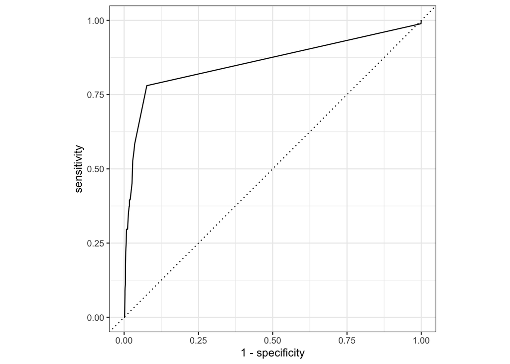

```r
cc_dt_final_fit %>% collect_predictions() %>%
  roc_curve(truth=default, .pred_Yes) %>%
  autoplot()
```